# Introduction and exploring raw data

## Getting a feel for your data

Cuando tenemos por primera vez en nuestras manos un conjunto de datos, lo primero que debemos de hacer es comprender su estructura. Existen una gran cantidad de funciones en R que nos proporcionan información respecto a los datos. Podemos hacer uso de la función **class()** para chequear la clase de cualquier objeto en R. La función **dim()** nos permite conocer la dimensión de nuestro objeto y la función **names()** para el caso de dataframes nos retorna los nombres de las columnas

```r
bmi <- read.csv("bmi_clean.csv")
#Vemos que clase de variable es bmi
class(bmi)
```

```
[1] "data.frame"
```

```r
#Vemos las dimensiones de bmi
dim(bmi)
```

```
[1] 199  30
```

```r
#Vemos los nombres de las columnas
names(bmi)
```

```
 [1] "Country" "Y1980"   "Y1981"   "Y1982"   "Y1983"   "Y1984"   "Y1985"   "Y1986"   "Y1987"   "Y1988"   "Y1989"   "Y1990"
[13] "Y1991"   "Y1992"   "Y1993"   "Y1994"   "Y1995"   "Y1996"   "Y1997"   "Y1998"   "Y1999"   "Y2000"   "Y2001"   "Y2002"
[25] "Y2003"   "Y2004"   "Y2005"   "Y2006"   "Y2007"   "Y2008"
```

## Viewing the structure of your data

Para ver la estructura de nuestro conjunto de datos podemos hacer uso de la función **str()**, esta función además de retornar la dimensión nos retorna el tipo de datos que es cada columna y nos muestra las primeras observaciones de cada columna. Sin embargo, el paquete **dplyr** dispone de la función **glimpse()** que se trata de una alternativa más limpia a **str()**. Podemos hacer uso de la función **summary()** para tener una mejor idea de como están distribuidos nuestros datos, esto nos puede revelar inusuales valores extremos, valores perdidos no esperados, etc. Para las variables de tipo character o factor, la función **summary()** nos revela el número de apariciones de cada uno de los valores.

```r
#Hacemos uso de la función str con nuestros datos
str(bmi)
```

```
'data.frame':   199 obs. of  30 variables:
 $ Country: Factor w/ 199 levels "Afghanistan",..: 1 2 3 4 5 6 7 8 9 10 ...
 $ Y1980  : num  21.5 25.2 22.3 25.7 20.9 ...
 $ Y1981  : num  21.5 25.2 22.3 25.7 20.9 ...
 $ Y1982  : num  21.5 25.3 22.4 25.7 20.9 ...
 $ Y1983  : num  21.4 25.3 22.5 25.8 20.9 ...
 $ Y1984  : num  21.4 25.3 22.6 25.8 20.9 ...
 $ Y1985  : num  21.4 25.3 22.7 25.9 20.9 ...
 $ Y1986  : num  21.4 25.3 22.8 25.9 21 ...
 $ Y1987  : num  21.4 25.3 22.8 25.9 21 ...
 $ Y1988  : num  21.3 25.3 22.9 26 21 ...
 $ Y1989  : num  21.3 25.3 23 26 21.1 ...
 $ Y1990  : num  21.2 25.3 23 26.1 21.1 ...
 $ Y1991  : num  21.2 25.3 23.1 26.2 21.1 ...
 $ Y1992  : num  21.1 25.2 23.2 26.2 21.1 ...
```

[output cut: 16 more lines]

```r
#Hacemos uso de la función glimpse
library(dplyr)
glimpse(bmi)
```

```
Observations: 199
Variables: 30
$ Country <fct> Afghanistan, Albania, Algeria, Andorra, Angola, Antigua and Barbuda, Argentina, Armenia, Australia, Austria...
$ Y1980   <dbl> 21.48678, 25.22533, 22.25703, 25.66652, 20.94876, 23.31424, 25.37913, 23.82469, 24.92729, 24.84097, 24.4937...
$ Y1981   <dbl> 21.46552, 25.23981, 22.34745, 25.70868, 20.94371, 23.39054, 25.44951, 23.86401, 25.00216, 24.88110, 24.5258...
$ Y1982   <dbl> 21.45145, 25.25636, 22.43647, 25.74681, 20.93754, 23.45883, 25.50242, 23.91023, 25.07660, 24.93482, 24.5606...
$ Y1983   <dbl> 21.43822, 25.27176, 22.52105, 25.78250, 20.93187, 23.53735, 25.55644, 23.95649, 25.14938, 24.98118, 24.6015...
$ Y1984   <dbl> 21.42734, 25.27901, 22.60633, 25.81874, 20.93569, 23.63584, 25.61271, 24.00181, 25.22894, 25.02208, 24.6412...
$ Y1985   <dbl> 21.41222, 25.28669, 22.69501, 25.85236, 20.94857, 23.73109, 25.66593, 24.04083, 25.31849, 25.06015, 24.6756...
$ Y1986   <dbl> 21.40132, 25.29451, 22.76979, 25.89089, 20.96030, 23.83449, 25.72364, 24.08736, 25.41017, 25.10680, 24.7190...
$ Y1987   <dbl> 21.37679, 25.30217, 22.84096, 25.93414, 20.98025, 23.93649, 25.78529, 24.13334, 25.50528, 25.14747, 24.7579...
$ Y1988   <dbl> 21.34018, 25.30450, 22.90644, 25.98477, 21.01375, 24.05364, 25.84428, 24.17219, 25.60001, 25.19333, 24.7889...
$ Y1989   <dbl> 21.29845, 25.31944, 22.97931, 26.04450, 21.05269, 24.16347, 25.88510, 24.19556, 25.70050, 25.24928, 24.8227...
$ Y1990   <dbl> 21.24818, 25.32357, 23.04600, 26.10936, 21.09007, 24.26782, 25.92482, 24.20618, 25.80568, 25.30882, 24.8316...
$ Y1991   <dbl> 21.20269, 25.28452, 23.11333, 26.17912, 21.12136, 24.36568, 25.99177, 24.19790, 25.90295, 25.37186, 24.8397...
```

[output cut: 17 more lines]

```r
#Hacemos un summary
summary(bmi)
```

```
                Country        Y1980           Y1981           Y1982           Y1983           Y1984           Y1985
 Afghanistan        :  1   Min.   :19.01   Min.   :19.04   Min.   :19.07   Min.   :19.10   Min.   :19.13   Min.   :19.16
 Albania            :  1   1st Qu.:21.27   1st Qu.:21.31   1st Qu.:21.36   1st Qu.:21.42   1st Qu.:21.45   1st Qu.:21.47
 Algeria            :  1   Median :23.31   Median :23.39   Median :23.46   Median :23.57   Median :23.64   Median :23.73
 Andorra            :  1   Mean   :23.15   Mean   :23.21   Mean   :23.26   Mean   :23.32   Mean   :23.37   Mean   :23.42
 Angola             :  1   3rd Qu.:24.82   3rd Qu.:24.89   3rd Qu.:24.94   3rd Qu.:25.02   3rd Qu.:25.06   3rd Qu.:25.11
 Antigua and Barbuda:  1   Max.   :28.12   Max.   :28.36   Max.   :28.58   Max.   :28.82   Max.   :29.05   Max.   :29.28
 (Other)            :193
     Y1986           Y1987           Y1988           Y1989           Y1990           Y1991           Y1992
 Min.   :19.20   Min.   :19.23   Min.   :19.27   Min.   :19.31   Min.   :19.35   Min.   :19.40   Min.   :19.45
 1st Qu.:21.49   1st Qu.:21.50   1st Qu.:21.52   1st Qu.:21.55   1st Qu.:21.57   1st Qu.:21.60   1st Qu.:21.65
 Median :23.82   Median :23.87   Median :23.93   Median :24.03   Median :24.14   Median :24.20   Median :24.19
 Mean   :23.48   Mean   :23.53   Mean   :23.59   Mean   :23.65   Mean   :23.71   Mean   :23.76   Mean   :23.82
 3rd Qu.:25.20   3rd Qu.:25.27   3rd Qu.:25.34   3rd Qu.:25.37   3rd Qu.:25.39   3rd Qu.:25.42   3rd Qu.:25.48
 Max.   :29.52   Max.   :29.75   Max.   :29.98   Max.   :30.20   Max.   :30.42   Max.   :30.64   Max.   :30.85

     Y1993           Y1994           Y1995           Y1996           Y1997           Y1998           Y1999
 Min.   :19.51   Min.   :19.59   Min.   :19.67   Min.   :19.71   Min.   :19.74   Min.   :19.77   Min.   :19.80
 1st Qu.:21.74   1st Qu.:21.76   1st Qu.:21.83   1st Qu.:21.89   1st Qu.:21.94   1st Qu.:22.00   1st Qu.:22.04
 Median :24.27   Median :24.36   Median :24.41   Median :24.42   Median :24.50   Median :24.49   Median :24.61
 Mean   :23.88   Mean   :23.94   Mean   :24.00   Mean   :24.07   Mean   :24.14   Mean   :24.21   Mean   :24.29
 3rd Qu.:25.54   3rd Qu.:25.62   3rd Qu.:25.70   3rd Qu.:25.78   3rd Qu.:25.85   3rd Qu.:25.94   3rd Qu.:26.01
 Max.   :31.04   Max.   :31.23   Max.   :31.41   Max.   :31.59   Max.   :31.77   Max.   :31.95   Max.   :32.13

     Y2000           Y2001           Y2002           Y2003           Y2004           Y2005           Y2006
 Min.   :19.83   Min.   :19.86   Min.   :19.84   Min.   :19.81   Min.   :19.79   Min.   :19.79   Min.   :19.80
 1st Qu.:22.12   1st Qu.:22.22   1st Qu.:22.29   1st Qu.:22.37   1st Qu.:22.45   1st Qu.:22.54   1st Qu.:22.63
 Median :24.66   Median :24.73   Median :24.81   Median :24.89   Median :25.00   Median :25.11   Median :25.24
 Mean   :24.36   Mean   :24.44   Mean   :24.52   Mean   :24.61   Mean   :24.70   Mean   :24.79   Mean   :24.89
 3rd Qu.:26.09   3rd Qu.:26.19   3rd Qu.:26.30   3rd Qu.:26.38   3rd Qu.:26.47   3rd Qu.:26.53   3rd Qu.:26.59
 Max.   :32.32   Max.   :32.51   Max.   :32.70   Max.   :32.90   Max.   :33.10   Max.   :33.30   Max.   :33.49

     Y2007           Y2008
 Min.   :19.83   Min.   :19.87
 1st Qu.:22.73   1st Qu.:22.83
 Median :25.36   Median :25.50
 Mean   :24.99   Mean   :25.10
 3rd Qu.:26.66   3rd Qu.:26.82
 Max.   :33.69   Max.   :33.90
```

## Looking at your data

La forma más básica de visualizar nuestros datos es mostrando estos por pantalla. Sin embargo cuando estamos tratando con conjuntos de datos grandes no es recomendable mostrar el dataset completo. Es por esto que R dispone de las funciones **head()** y **tail()**. La función **head()** por defecto nos permite mostrar las 6 primeras observaciones de nuestro conjunto de datos, dispone del parámetro **n** a partir del cual podemos ajustar el número de observaciones que deseamos ver. Por otro lado, la función **tail()** nos permite observar por defecto las últimas 6 observaciones de nuestro conjunto de datos, al igual que **head()** dispone del parámetro **n** que nos permite ajustar el número de observaciones.

```r
#Hacemos uso de la función head()
head(bmi)
```

|  | Country | Y1980 | Y1981 | Y1982 | Y1983 | Y1984 | Y1985 | Y1986 | Y1987 | Y1988 | Y1989 | Y1990 | Y1991 | Y1992 | Y1993 | Y1994 | Y1995 | Y1996 | Y1997 | Y1998 | Y1999 | Y2000 | Y2001 | Y2002 | Y2003 | Y2004 | Y2005 | Y2006 | Y2007 | … |
| --- | --- | --- | --- | --- | --- | --- | --- | --- | --- | --- | --- | --- | --- | --- | --- | --- | --- | --- | --- | --- | --- | --- | --- | --- | --- | --- | --- | --- | --- | --- |
| 1 | Afghanistan | 21.48678 | 21.46552 | 21.45145 | 21.43822 | 21.42734 | 21.41222 | 21.40132 | 21.37679 | 21.34018 | 21.29845 | 21.24818 | 21.20269 | 21.14238 | 21.06376 | 20.97987 | 20.91132 | 20.85155 | 20.81307 | 20.78591 | 20.75469 | 20.69521 | 20.62643 | 20.59848 | 20.58706 | 20.57759 | 20.58084 | 20.58749 | 20.60246 | … |
| 2 | Albania | 25.22533 | 25.23981 | 25.25636 | 25.27176 | 25.27901 | 25.28669 | 25.29451 | 25.30217 | 25.30450 | 25.31944 | 25.32357 | 25.28452 | 25.23077 | 25.21192 | 25.22115 | 25.25874 | 25.31097 | 25.33988 | 25.39116 | 25.46555 | 25.55835 | 25.66701 | 25.77167 | 25.87274 | 25.98136 | 26.08939 | 26.20867 | 26.32753 | … |
| 3 | Algeria | 22.25703 | 22.34745 | 22.43647 | 22.52105 | 22.60633 | 22.69501 | 22.76979 | 22.84096 | 22.90644 | 22.97931 | 23.04600 | 23.11333 | 23.18776 | 23.25764 | 23.32273 | 23.39526 | 23.46811 | 23.54160 | 23.61592 | 23.69486 | 23.77659 | 23.86256 | 23.95294 | 24.05243 | 24.15957 | 24.27001 | 24.38270 | 24.48846 | … |
| 4 | Andorra | 25.66652 | 25.70868 | 25.74681 | 25.78250 | 25.81874 | 25.85236 | 25.89089 | 25.93414 | 25.98477 | 26.04450 | 26.10936 | 26.17912 | 26.24017 | 26.30356 | 26.36793 | 26.43569 | 26.50769 | 26.58255 | 26.66337 | 26.75078 | 26.83179 | 26.92373 | 27.02525 | 27.12481 | 27.23107 | 27.32827 | 27.43588 | 27.53363 | … |
| 5 | Angola | 20.94876 | 20.94371 | 20.93754 | 20.93187 | 20.93569 | 20.94857 | 20.96030 | 20.98025 | 21.01375 | 21.05269 | 21.09007 | 21.12136 | 21.14987 | 21.13938 | 21.14186 | 21.16022 | 21.19076 | 21.22621 | 21.27082 | 21.31954 | 21.37480 | 21.43664 | 21.51765 | 21.59924 | 21.69218 | 21.80564 | 21.93881 | 22.08962 | … |
| 6 | Antigua and Barbuda | 23.31424 | 23.39054 | 23.45883 | 23.53735 | 23.63584 | 23.73109 | 23.83449 | 23.93649 | 24.05364 | 24.16347 | 24.26782 | 24.36568 | 24.45644 | 24.54096 | 24.60945 | 24.66461 | 24.72544 | 24.78714 | 24.84936 | 24.91721 | 24.99158 | 25.05857 | 25.13039 | 25.20713 | 25.29898 | 25.39965 | 25.51382 | 25.64247 | … |

```r
#Hacemos uso de head() con n= 10
head(bmi, n= 10)
```

|  | Country | Y1980 | Y1981 | Y1982 | Y1983 | Y1984 | Y1985 | Y1986 | Y1987 | Y1988 | Y1989 | Y1990 | Y1991 | Y1992 | Y1993 | Y1994 | Y1995 | Y1996 | Y1997 | Y1998 | Y1999 | Y2000 | Y2001 | Y2002 | Y2003 | Y2004 | Y2005 | Y2006 | Y2007 | … |
| --- | --- | --- | --- | --- | --- | --- | --- | --- | --- | --- | --- | --- | --- | --- | --- | --- | --- | --- | --- | --- | --- | --- | --- | --- | --- | --- | --- | --- | --- | --- |
| 1 | Afghanistan | 21.48678 | 21.46552 | 21.45145 | 21.43822 | 21.42734 | 21.41222 | 21.40132 | 21.37679 | 21.34018 | 21.29845 | 21.24818 | 21.20269 | 21.14238 | 21.06376 | 20.97987 | 20.91132 | 20.85155 | 20.81307 | 20.78591 | 20.75469 | 20.69521 | 20.62643 | 20.59848 | 20.58706 | 20.57759 | 20.58084 | 20.58749 | 20.60246 | … |
| 2 | Albania | 25.22533 | 25.23981 | 25.25636 | 25.27176 | 25.27901 | 25.28669 | 25.29451 | 25.30217 | 25.30450 | 25.31944 | 25.32357 | 25.28452 | 25.23077 | 25.21192 | 25.22115 | 25.25874 | 25.31097 | 25.33988 | 25.39116 | 25.46555 | 25.55835 | 25.66701 | 25.77167 | 25.87274 | 25.98136 | 26.08939 | 26.20867 | 26.32753 | … |
| 3 | Algeria | 22.25703 | 22.34745 | 22.43647 | 22.52105 | 22.60633 | 22.69501 | 22.76979 | 22.84096 | 22.90644 | 22.97931 | 23.04600 | 23.11333 | 23.18776 | 23.25764 | 23.32273 | 23.39526 | 23.46811 | 23.54160 | 23.61592 | 23.69486 | 23.77659 | 23.86256 | 23.95294 | 24.05243 | 24.15957 | 24.27001 | 24.38270 | 24.48846 | … |
| 4 | Andorra | 25.66652 | 25.70868 | 25.74681 | 25.78250 | 25.81874 | 25.85236 | 25.89089 | 25.93414 | 25.98477 | 26.04450 | 26.10936 | 26.17912 | 26.24017 | 26.30356 | 26.36793 | 26.43569 | 26.50769 | 26.58255 | 26.66337 | 26.75078 | 26.83179 | 26.92373 | 27.02525 | 27.12481 | 27.23107 | 27.32827 | 27.43588 | 27.53363 | … |
| 5 | Angola | 20.94876 | 20.94371 | 20.93754 | 20.93187 | 20.93569 | 20.94857 | 20.96030 | 20.98025 | 21.01375 | 21.05269 | 21.09007 | 21.12136 | 21.14987 | 21.13938 | 21.14186 | 21.16022 | 21.19076 | 21.22621 | 21.27082 | 21.31954 | 21.37480 | 21.43664 | 21.51765 | 21.59924 | 21.69218 | 21.80564 | 21.93881 | 22.08962 | … |
| 6 | Antigua and Barbuda | 23.31424 | 23.39054 | 23.45883 | 23.53735 | 23.63584 | 23.73109 | 23.83449 | 23.93649 | 24.05364 | 24.16347 | 24.26782 | 24.36568 | 24.45644 | 24.54096 | 24.60945 | 24.66461 | 24.72544 | 24.78714 | 24.84936 | 24.91721 | 24.99158 | 25.05857 | 25.13039 | 25.20713 | 25.29898 | 25.39965 | 25.51382 | 25.64247 | … |
| 7 | Argentina | 25.37913 | 25.44951 | 25.50242 | 25.55644 | 25.61271 | 25.66593 | 25.72364 | 25.78529 | 25.84428 | 25.88510 | 25.92482 | 25.99177 | 26.07642 | 26.17288 | 26.27872 | 26.37522 | 26.47182 | 26.57778 | 26.68714 | 26.79005 | 26.88103 | 26.96067 | 26.99882 | 27.04738 | 27.11001 | 27.18941 | 27.28179 | 27.38889 | … |
| 8 | Armenia | 23.82469 | 23.86401 | 23.91023 | 23.95649 | 24.00181 | 24.04083 | 24.08736 | 24.13334 | 24.17219 | 24.19556 | 24.20618 | 24.19790 | 24.12982 | 24.05854 | 24.02297 | 24.01570 | 24.02627 | 24.03885 | 24.07100 | 24.11699 | 24.18045 | 24.26670 | 24.37698 | 24.50332 | 24.64178 | 24.81447 | 24.99160 | 25.17590 | … |
| 9 | Australia | 24.92729 | 25.00216 | 25.07660 | 25.14938 | 25.22894 | 25.31849 | 25.41017 | 25.50528 | 25.60001 | 25.70050 | 25.80568 | 25.90295 | 26.00624 | 26.10586 | 26.20077 | 26.29241 | 26.38256 | 26.47351 | 26.56314 | 26.65506 | 26.74486 | 26.84397 | 26.93858 | 27.03801 | 27.13871 | 27.24614 | 27.35267 | 27.45878 | … |
| 10 | Austria | 24.84097 | 24.88110 | 24.93482 | 24.98118 | 25.02208 | 25.06015 | 25.10680 | 25.14747 | 25.19333 | 25.24928 | 25.30882 | 25.37186 | 25.43668 | 25.50507 | 25.56626 | 25.61814 | 25.66410 | 25.71737 | 25.75996 | 25.81773 | 25.87471 | 25.93806 | 25.99583 | 26.06356 | 26.14360 | 26.21107 | 26.29374 | 26.38136 | … |

```r
#Hacemos uso de tail
tail(bmi)
```

|  | Country | Y1980 | Y1981 | Y1982 | Y1983 | Y1984 | Y1985 | Y1986 | Y1987 | Y1988 | Y1989 | Y1990 | Y1991 | Y1992 | Y1993 | Y1994 | Y1995 | Y1996 | Y1997 | Y1998 | Y1999 | Y2000 | Y2001 | Y2002 | Y2003 | Y2004 | Y2005 | Y2006 | Y2007 | … |
| --- | --- | --- | --- | --- | --- | --- | --- | --- | --- | --- | --- | --- | --- | --- | --- | --- | --- | --- | --- | --- | --- | --- | --- | --- | --- | --- | --- | --- | --- | --- |
| 194 | Venezuela | 24.58052 | 24.69666 | 24.80082 | 24.89208 | 24.98440 | 25.07104 | 25.15587 | 25.24624 | 25.35274 | 25.43322 | 25.52678 | 25.63444 | 25.75528 | 25.87036 | 25.97218 | 26.08046 | 26.18272 | 26.29177 | 26.40105 | 26.50035 | 26.61021 | 26.71688 | 26.79210 | 26.85498 | 26.95162 | 27.05633 | 27.17698 | 27.30849 | … |
| 195 | Vietnam | 19.01394 | 19.03902 | 19.06804 | 19.09675 | 19.13046 | 19.16397 | 19.19740 | 19.23481 | 19.27090 | 19.31105 | 19.35150 | 19.39625 | 19.45212 | 19.51493 | 19.58757 | 19.66996 | 19.75854 | 19.84794 | 19.93580 | 20.02081 | 20.10343 | 20.18623 | 20.27145 | 20.36402 | 20.46585 | 20.57277 | 20.68655 | 20.80189 | … |
| 196 | West Bank and Gaza | 24.31624 | 24.40192 | 24.48713 | 24.57107 | 24.65582 | 24.74148 | 24.82984 | 24.91615 | 25.00108 | 25.08593 | 25.17834 | 25.27187 | 25.37683 | 25.48893 | 25.61249 | 25.73496 | 25.87428 | 26.01468 | 26.15144 | 26.28240 | 26.39074 | 26.45700 | 26.48925 | 26.51152 | 26.52924 | 26.54329 | 26.54449 | 26.55460 | … |
| 197 | Yemen, Rep. | 22.90384 | 22.96813 | 23.02669 | 23.07279 | 23.12566 | 23.16944 | 23.20933 | 23.25043 | 23.29401 | 23.33879 | 23.38236 | 23.42152 | 23.46544 | 23.51371 | 23.56154 | 23.61684 | 23.66973 | 23.72737 | 23.79152 | 23.85482 | 23.92467 | 23.99129 | 24.05692 | 24.12459 | 24.19204 | 24.25638 | 24.32120 | 24.37949 | … |
| 198 | Zambia | 19.66295 | 19.69512 | 19.72538 | 19.75420 | 19.78070 | 19.80335 | 19.82396 | 19.85065 | 19.88320 | 19.92451 | 19.96680 | 20.00746 | 20.04096 | 20.07781 | 20.09502 | 20.09977 | 20.11009 | 20.12375 | 20.13349 | 20.15094 | 20.17261 | 20.20266 | 20.24298 | 20.29474 | 20.35966 | 20.43398 | 20.51422 | 20.59770 | … |
| 199 | Zimbabwe | 21.46989 | 21.48867 | 21.50738 | 21.52936 | 21.53383 | 21.54341 | 21.54859 | 21.54590 | 21.55396 | 21.56903 | 21.58005 | 21.59694 | 21.59010 | 21.58547 | 21.59029 | 21.58986 | 21.60362 | 21.62721 | 21.65496 | 21.68873 | 21.72652 | 21.76514 | 21.79645 | 21.82499 | 21.85806 | 21.89495 | 21.93371 | 21.97405 | … |

```r
#Hacemos uso de tail con n= 8
tail(bmi, n= 8)
```

|  | Country | Y1980 | Y1981 | Y1982 | Y1983 | Y1984 | Y1985 | Y1986 | Y1987 | Y1988 | Y1989 | Y1990 | Y1991 | Y1992 | Y1993 | Y1994 | Y1995 | Y1996 | Y1997 | Y1998 | Y1999 | Y2000 | Y2001 | Y2002 | Y2003 | Y2004 | Y2005 | Y2006 | Y2007 | … |
| --- | --- | --- | --- | --- | --- | --- | --- | --- | --- | --- | --- | --- | --- | --- | --- | --- | --- | --- | --- | --- | --- | --- | --- | --- | --- | --- | --- | --- | --- | --- |
| 192 | Uzbekistan | 24.56500 | 24.60077 | 24.62187 | 24.64780 | 24.66890 | 24.69832 | 24.72305 | 24.74603 | 24.77115 | 24.78287 | 24.78404 | 24.77866 | 24.75026 | 24.73165 | 24.71118 | 24.69517 | 24.67727 | 24.68203 | 24.69876 | 24.72082 | 24.75326 | 24.79418 | 24.83998 | 24.88965 | 24.95455 | 25.03331 | 25.12717 | 25.22226 | … |
| 193 | Vanuatu | 23.20701 | 23.32990 | 23.46016 | 23.60431 | 23.75134 | 23.89466 | 24.03171 | 24.15571 | 24.27529 | 24.39727 | 24.52964 | 24.66287 | 24.79143 | 24.92541 | 25.05856 | 25.19282 | 25.32325 | 25.45811 | 25.59565 | 25.72398 | 25.85208 | 25.96032 | 26.05661 | 26.16060 | 26.27087 | 26.38887 | 26.51376 | 26.64903 | … |
| 194 | Venezuela | 24.58052 | 24.69666 | 24.80082 | 24.89208 | 24.98440 | 25.07104 | 25.15587 | 25.24624 | 25.35274 | 25.43322 | 25.52678 | 25.63444 | 25.75528 | 25.87036 | 25.97218 | 26.08046 | 26.18272 | 26.29177 | 26.40105 | 26.50035 | 26.61021 | 26.71688 | 26.79210 | 26.85498 | 26.95162 | 27.05633 | 27.17698 | 27.30849 | … |
| 195 | Vietnam | 19.01394 | 19.03902 | 19.06804 | 19.09675 | 19.13046 | 19.16397 | 19.19740 | 19.23481 | 19.27090 | 19.31105 | 19.35150 | 19.39625 | 19.45212 | 19.51493 | 19.58757 | 19.66996 | 19.75854 | 19.84794 | 19.93580 | 20.02081 | 20.10343 | 20.18623 | 20.27145 | 20.36402 | 20.46585 | 20.57277 | 20.68655 | 20.80189 | … |
| 196 | West Bank and Gaza | 24.31624 | 24.40192 | 24.48713 | 24.57107 | 24.65582 | 24.74148 | 24.82984 | 24.91615 | 25.00108 | 25.08593 | 25.17834 | 25.27187 | 25.37683 | 25.48893 | 25.61249 | 25.73496 | 25.87428 | 26.01468 | 26.15144 | 26.28240 | 26.39074 | 26.45700 | 26.48925 | 26.51152 | 26.52924 | 26.54329 | 26.54449 | 26.55460 | … |
| 197 | Yemen, Rep. | 22.90384 | 22.96813 | 23.02669 | 23.07279 | 23.12566 | 23.16944 | 23.20933 | 23.25043 | 23.29401 | 23.33879 | 23.38236 | 23.42152 | 23.46544 | 23.51371 | 23.56154 | 23.61684 | 23.66973 | 23.72737 | 23.79152 | 23.85482 | 23.92467 | 23.99129 | 24.05692 | 24.12459 | 24.19204 | 24.25638 | 24.32120 | 24.37949 | … |
| 198 | Zambia | 19.66295 | 19.69512 | 19.72538 | 19.75420 | 19.78070 | 19.80335 | 19.82396 | 19.85065 | 19.88320 | 19.92451 | 19.96680 | 20.00746 | 20.04096 | 20.07781 | 20.09502 | 20.09977 | 20.11009 | 20.12375 | 20.13349 | 20.15094 | 20.17261 | 20.20266 | 20.24298 | 20.29474 | 20.35966 | 20.43398 | 20.51422 | 20.59770 | … |
| 199 | Zimbabwe | 21.46989 | 21.48867 | 21.50738 | 21.52936 | 21.53383 | 21.54341 | 21.54859 | 21.54590 | 21.55396 | 21.56903 | 21.58005 | 21.59694 | 21.59010 | 21.58547 | 21.59029 | 21.58986 | 21.60362 | 21.62721 | 21.65496 | 21.68873 | 21.72652 | 21.76514 | 21.79645 | 21.82499 | 21.85806 | 21.89495 | 21.93371 | 21.97405 | … |

## Visualizing your data

Existe una gran variedad de formas a la hora de visualizar nuestros datos. Los histogramas y los scatter plots son dos tipos de visualizaciones que nos pueden ayudar a detectar valores extremos o sospechosos. El histograma se puede crear a partir de la función **hist()**, que toma como argumento principal un vector, por otro lado, los gráficos de tipo scatter puede ser creados a partir de la función **plot()** que toma como argumento principal dos vectores.

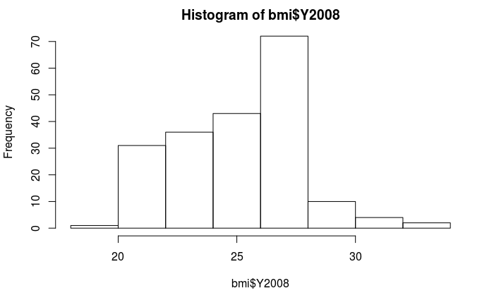

```r
#Nos creamos un histograma para el año 2008
hist(bmi$Y2008)
```

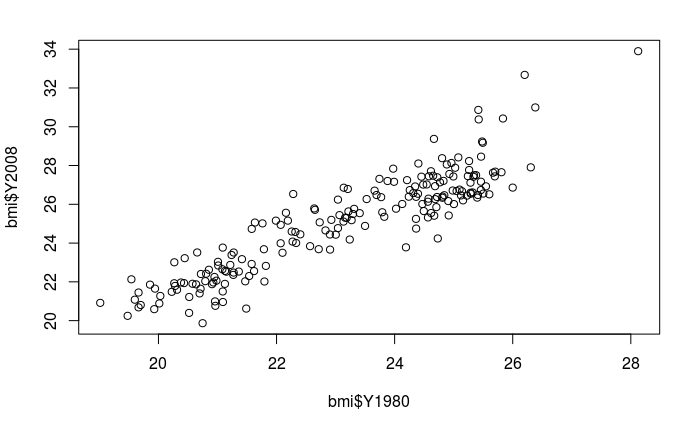

```r
#Hacemos un scatter con el bmi de 1980 y 2008
plot(bmi$Y1980, bmi$Y2008)
```